# Hospital Analysis

Michael Barr, ACAS, MAAA, CPCU

07 April, 2021

# 1 Environment

```r
options(na.action = "na.fail",
        scipen = 999)
options(dplyr.summarise.inform = FALSE)
knitr::opts_chunk$set(cache.path = "cache/",
                      warning = FALSE)
library(dplyr)
library(magrittr)
library(bea.R)
library(jsonlite)
library(blsAPI)
library(zoo)
library(forecast)
library(ggplot2)
library(ggfortify)
library(tempdisagg)
library(glmnet)
library(mgcv)
```

# 2 Data Prep

I’ll set up my data for modeling here.

## 2.1 BEA

Starting with the US Bureau of Economic Analysis features.

### 2.1.1 API

Although the data was provided in an excel file, I want to demonstrate how we can pull this from public APIs. This is the starting point for production code - I do not incorporate any exception handling/failover here. I’m only providing a list of “Line Descriptions” of interest here (`bea.csv`), which I obtained from the excel file.

I’m only pulling years 2014 through 2020 since the dependent variable (Hospital Volume, YoY%) is only observed in this time range.s

```r
bea_key <- "C9735BB9-9D83-4894-B843-E96C7BB440E3"
bea_codes <- read.csv("bea.csv", header = FALSE) %>%
  pull(V1)

beaSpecs <- list(
  'UserID' = bea_key ,
  'Method' = 'GetData',
  'DatasetName' = 'NIUnderlyingDetail',
  'TableName' = 'U20403',
  'Frequency' = 'M',
  'Year' = '2014,2015,2016,2017,2018,2019,2020',
  'ResultFormat' = 'json')

dat.bea <- beaGet(beaSpecs) %>%
  filter(LineDescription %in% trimws(bea_codes))

head(dat.bea)
```

| TableName | SeriesCode | LineNumber | LineDescription | METRIC_NAME | CL_UNIT | UNIT_MULT | DataValue_2014M01 | DataValue_2014M02 | DataValue_2014M03 | DataValue_2014M04 | DataValue_2014M05 | DataValue_2014M06 | DataValue_2014M07 | DataValue_2014M08 | DataValue_2014M09 | DataValue_2014M10 | DataValue_2014M11 | DataValue_2014M12 | DataValue_2015M01 | DataValue_2015M02 | DataValue_2015M03 | DataValue_2015M04 | DataValue_2015M05 | DataValue_2015M06 | DataValue_2015M07 | DataValue_2015M08 | DataValue_2015M09 | DataValue_2015M10 | DataValue_2015M11 | … |
| --- | --- | --- | --- | --- | --- | --- | --- | --- | --- | --- | --- | --- | --- | --- | --- | --- | --- | --- | --- | --- | --- | --- | --- | --- | --- | --- | --- | --- | --- | --- |
| U20403 | DTAERA | 64 | Therapeutic appliances and equipment (42) | Fisher Quantity Index | Level | 0 | 102.975 | 103.732 | 103.908 | 104.760 | 105.923 | 106.157 | 106.360 | 107.174 | 107.414 | 108.592 | 108.297 | 106.734 | 110.796 | 110.513 | 109.862 | 109.835 | 109.013 | 110.489 | 112.484 | 113.267 | 109.289 | 112.189 | 112.991 | … |
| U20403 | DTMERA | 65 | Therapeutic medical equipment | Fisher Quantity Index | Level | 0 | 104.980 | 106.482 | 106.748 | 107.391 | 108.974 | 109.684 | 109.390 | 110.603 | 111.129 | 111.888 | 112.238 | 111.478 | 115.636 | 115.462 | 115.964 | 115.695 | 115.246 | 117.418 | 119.601 | 120.514 | 118.450 | 120.819 | 121.774 | … |
| U20403 | DEYERA | 66 | Corrective eyeglasses and contact lenses | Fisher Quantity Index | Level | 0 | 101.498 | 101.713 | 101.824 | 102.826 | 103.687 | 103.579 | 104.140 | 104.665 | 104.697 | 106.177 | 105.416 | 103.275 | 107.266 | 106.906 | 105.429 | 105.575 | 104.484 | 105.460 | 107.319 | 108.008 | 102.662 | 105.941 | 106.634 | … |
| U20403 | DPHMRA | 119 | Pharmaceutical and other medical products (40 and 41) | Fisher Quantity Index | Level | 0 | 108.324 | 108.559 | 110.241 | 110.328 | 111.683 | 111.591 | 112.107 | 113.237 | 113.507 | 113.599 | 113.786 | 114.768 | 114.883 | 113.988 | 115.171 | 115.277 | 116.126 | 116.944 | 118.043 | 118.921 | 118.917 | 119.797 | 119.996 | … |
| U20403 | DPNPRA | 120 | Pharmaceutical products | Fisher Quantity Index | Level | 0 | 108.369 | 108.587 | 110.287 | 110.366 | 111.718 | 111.615 | 112.141 | 113.269 | 113.536 | 113.620 | 113.805 | 114.808 | 114.875 | 113.970 | 115.162 | 115.273 | 116.137 | 116.940 | 118.026 | 118.904 | 118.924 | 119.787 | 119.977 | … |
| U20403 | DRXDRA | 121 | Prescription drugs | Fisher Quantity Index | Level | 0 | 109.062 | 109.093 | 111.074 | 111.164 | 112.615 | 112.431 | 113.051 | 114.078 | 114.660 | 114.229 | 114.381 | 115.653 | 115.376 | 114.466 | 115.547 | 115.786 | 116.797 | 117.369 | 118.587 | 119.566 | 119.411 | 120.515 | 120.589 | … |

### 2.1.2 Cleaning

Each row looks like it corresponds to a distinct `SeriesCode`, so let’s confirm.

```r
table(dat.bea$SeriesCode)
```

```
##
## DDENRA DEYERA DFPHRA DFPNRA DGVHRA DHHCRA DHINRA DHLCRA DHPNRA DHSPRA DMINRA
##      1      1      1      1      1      1      1      2      1      1      1
## DMLBRA DNPHRA DNPNRA DNRDRA DNRSRA DOMDRA DOMORA DOMPRA DOMSRA DOUTRA DPHMRA
##      1      1      1      1      1      1      1      1      1      1      1
## DPHYRA DPMSRA DPNPRA DRXDRA DTAERA DTMERA
##      1      1      1      1      1      1
```

There are 2 entries for “DHLCRA”.

```r
dat.bea %>%
  filter(SeriesCode == "DHLCRA") %>%
  select(1:5)
```

| TableName | SeriesCode | LineNumber | LineDescription | METRIC_NAME |
| --- | --- | --- | --- | --- |
| U20403 | DHLCRA | 168 | Health care | Fisher Quantity Index |
| U20403 | DHLCRA | 383 | Market-based PCE health care | Fisher Quantity Index |

We will create a unique key using both `SeriesCode` and `LineNumber`

```r
dat.bea %<>%
  mutate(SeriesLine = paste0(SeriesCode, "_", LineNumber)) %>%
  select(-c(SeriesCode, LineNumber)) %>%
  relocate(SeriesLine, .after = TableName)
```

Finally, we need the data in wide format - each row a month, and each column a variable

```r
wide.bea <- dat.bea %>%
  select(SeriesLine, LineDescription, 7:90) %>%
  tidyr::gather(key = "period", value = "xit", -c(1:2)) %>%
  mutate(year = substr(period, 11, 14) %>% as.numeric,
         month = substr(period, 16, 17) %>% as.numeric) %>%
  select(-c(period, LineDescription)) %>%
  relocate(xit, .after = last_col()) %>%
  arrange(SeriesLine, year, month) %>%
  tidyr::pivot_wider(id_cols = c(SeriesLine, year, month),
                     names_from = SeriesLine,
                     values_from = xit)

head(wide.bea)
```

| year | month | DDENRA_171 | DEYERA_66 | DFPHRA_181 | DFPNRA_185 | DGVHRA_182 | DHHCRA_173 | DHINRA_271 | DHLCRA_168 | DHLCRA_383 | DHPNRA_178 | DHSPRA_179 | DMINRA_272 | DMLBRA_174 | DNPHRA_180 | DNPNRA_184 | DNRDRA_122 | DNRSRA_183 | DOMDRA_175 | DOMORA_177 | DOMPRA_123 | DOMSRA_176 | DOUTRA_169 | DPHMRA_119 | DPHYRA_170 | DPMSRA_172 | DPNPRA_120 | DRXDRA_121 | DTAERA_64 | … |
| --- | --- | --- | --- | --- | --- | --- | --- | --- | --- | --- | --- | --- | --- | --- | --- | --- | --- | --- | --- | --- | --- | --- | --- | --- | --- | --- | --- | --- | --- | --- |
| 2014 | 1 | 97.259 | 101.498 | 96.342 | 102.329 | 104.789 | 106.196 | 113.838 | 101.102 | 101.102 | 100.914 | 100.882 | 114.743 | 98.288 | 100.602 | 98.666 | 104.740 | 101.086 | 101.816 | 101.717 | 104.781 | 101.855 | 101.332 | 108.324 | 101.454 | 102.724 | 108.369 | 109.062 | 102.975 | … |
| 2014 | 2 | 97.126 | 101.713 | 96.580 | 101.837 | 105.236 | 106.978 | 115.236 | 100.945 | 100.945 | 100.522 | 100.506 | 116.284 | 96.905 | 99.875 | 98.241 | 105.956 | 100.616 | 101.760 | 101.907 | 106.340 | 101.702 | 101.459 | 108.559 | 101.704 | 102.762 | 108.587 | 109.093 | 103.732 | … |
| 2014 | 3 | 97.229 | 101.824 | 97.548 | 101.447 | 105.710 | 107.406 | 116.492 | 101.298 | 101.298 | 100.814 | 100.879 | 117.638 | 97.226 | 100.109 | 98.595 | 106.143 | 100.479 | 102.509 | 102.978 | 106.658 | 102.323 | 101.888 | 110.241 | 102.105 | 103.363 | 110.287 | 111.074 | 103.908 | … |
| 2014 | 4 | 97.574 | 102.826 | 99.343 | 101.139 | 106.219 | 108.318 | 117.689 | 102.252 | 102.252 | 101.853 | 102.083 | 118.906 | 99.260 | 101.402 | 99.711 | 106.162 | 100.655 | 104.205 | 104.938 | 107.348 | 103.915 | 102.738 | 110.328 | 102.665 | 104.863 | 110.366 | 111.164 | 104.760 | … |
| 2014 | 5 | 97.944 | 103.687 | 100.696 | 101.450 | 106.683 | 108.751 | 118.721 | 103.033 | 103.033 | 102.722 | 103.035 | 119.957 | 100.650 | 102.421 | 100.376 | 106.978 | 101.085 | 105.304 | 106.364 | 108.971 | 104.884 | 103.410 | 111.683 | 103.246 | 105.795 | 111.718 | 112.615 | 105.923 | … |
| 2014 | 6 | 98.336 | 103.579 | 101.733 | 102.110 | 107.097 | 108.760 | 119.611 | 103.670 | 103.670 | 103.467 | 103.841 | 120.821 | 101.391 | 103.297 | 100.328 | 107.313 | 101.505 | 105.859 | 107.250 | 109.714 | 105.307 | 103.918 | 111.591 | 103.845 | 106.206 | 111.615 | 112.431 | 106.157 | … |

### 2.1.3 API Note

While a maintained R interface to the API is nice to have for R users, it is often not available. We can get the same result from this API writing the request string directly, as follows:

```r
## Not run
dat.bea <- paste0("https://apps.bea.gov/api/data?&",
                  "UserID=", bea_key, "&",
                  "method=GetData&",
                  "datasetname=NIUnderlyingDetail&",
                  "TableName=U20403&",
                  "Frequency=M&",
                  "Year=2014,2015,2016,2017,2018,2019,2020&",
                  "ResultFormat=JSON") %>%
  fromJSON(.)
```

## 2.2 BLS

Now we perform the same steps for Bureau of Labor Statistics (BLS) data before binding the two `mts` (multivariate time series) objects together

### 2.2.1 API

The BLS also provides an API, and there is an R interface available as well.

```r
bls_key <- "280f312193354f37b12042f29f711c0e"
bls_codes <- read.csv("bls.csv") %>%
  pull(Series)

for(i in 1:ceiling(length(bls_codes)/50)) {

  j <- min(i*50, length(bls_codes)) ## ending index of bls codes to submit in request i

  req <- list(
    'registrationkey'= bls_key,
    'seriesid'= bls_codes[((i-1)*50 + 1):j],
    'startyear'= 2014,
    'endyear'= 2020)
  if(i == 1) {
    dat.bls <- blsAPI(req, api_version = 2, return_data_frame = TRUE)
  } else {
    dat.bls %<>% rbind(., blsAPI(req, api_version = 2, return_data_frame = TRUE) )
  }
}

dat.bls %<>% as_tibble()
dat.bls
```

| year | period | periodName | value | seriesID |
| --- | --- | --- | --- | --- |
| 2020 | M12 | December | 15979.3 | CES6562000101 |
| 2020 | M11 | November | 15935.4 | CES6562000101 |
| 2020 | M10 | October | 15905.9 | CES6562000101 |
| 2020 | M09 | September | 15835.9 | CES6562000101 |
| 2020 | M08 | August | 15758.3 | CES6562000101 |
| 2020 | M07 | July | 15686.2 | CES6562000101 |
| 2020 | M06 | June | 15544.2 | CES6562000101 |
| 2020 | M05 | May | 15187.0 | CES6562000101 |
| 2020 | M04 | April | 14875.5 | CES6562000101 |
| 2020 | M03 | March | 16397.4 | CES6562000101 |

[output cut: 9990 more lines]

### 2.2.2 Cleaning

Let’s confirm we got results for all of the original codes

```r
unique(dat.bls$seriesID) %>% length == length(bls_codes)
```

```
## [1] TRUE
```

Now we can restructure the data in wide format:

```r
wide.bls <- dat.bls %>%
  mutate(month = substr(period, 2, 3) %>% as.integer) %>%
  select(seriesID, year, month, value) %>%
  tidyr::pivot_wider(id_cols = c(seriesID, year, month),
                     names_from = seriesID,
                     values_from = value) %>%
  arrange(year, month)

wide.bls
```

| year | month | CES6562000101 | CEU6562000101 | CES6562111101 | CEU6562111101 | CES6562111201 | CEU6562111201 | CES6562120001 | CEU6562120001 | CES6562131001 | CEU6562131001 | CES6562132001 | CEU6562132001 | CES6562151101 | CEU6562151101 | CES6562151201 | CEU6562151201 | CES6562160001 | CEU6562160001 | CES6562210001 | CEU6562210001 | CES6562220001 | CEU6562220001 | CES6562310001 | CEU6562310001 | CES6562331201 | CEU6562331201 | CES6562000107 | CEU6562000107 | … |
| --- | --- | --- | --- | --- | --- | --- | --- | --- | --- | --- | --- | --- | --- | --- | --- | --- | --- | --- | --- | --- | --- | --- | --- | --- | --- | --- | --- | --- | --- | --- |
| 2014 | 1 | 14555.5 | 14514.3 | 2339.3 | 2338.0 | 49.0 | 48.6 | 877.8 | 875.2 | 127.4 | 126.4 | 122.2 | 121.6 | 177.6 | 177.6 | 67.8 | 67.0 | 1244.1 | 1237.9 | 4427.6 | 4423.9 | 119.4 | 118.4 | 1648.1 | 1641.2 | 390.2 | 388.3 | 32.9 | 32.9 | … |
| 2014 | 2 | 14571.8 | 14522.3 | 2346.8 | 2341.4 | 49.4 | 48.9 | 878.9 | 875.5 | 127.6 | 127.3 | 122.6 | 122.1 | 178.7 | 178.6 | 67.2 | 66.9 | 1242.7 | 1233.6 | 4431.3 | 4425.2 | 119.5 | 119.0 | 1650.5 | 1641.0 | 392.0 | 391.1 | 32.9 | 33.0 | … |
| 2014 | 3 | 14594.6 | 14563.0 | 2351.7 | 2347.7 | 49.9 | 49.3 | 883.9 | 879.2 | 126.8 | 126.4 | 123.0 | 122.3 | 180.0 | 180.3 | 66.8 | 66.8 | 1245.3 | 1240.0 | 4433.5 | 4432.9 | 120.8 | 120.6 | 1651.2 | 1644.3 | 392.6 | 391.7 | 32.9 | 33.0 | … |
| 2014 | 4 | 14606.4 | 14583.8 | 2352.1 | 2347.6 | 50.9 | 50.5 | 881.9 | 879.7 | 125.0 | 126.4 | 123.7 | 123.3 | 180.9 | 181.2 | 67.0 | 67.2 | 1247.1 | 1245.9 | 4431.0 | 4423.8 | 122.1 | 121.6 | 1652.2 | 1648.7 | 394.0 | 393.1 | 33.0 | 32.8 | … |
| 2014 | 5 | 14637.5 | 14633.5 | 2355.2 | 2350.7 | 49.8 | 49.5 | 882.9 | 882.2 | 125.8 | 126.0 | 123.3 | 123.8 | 181.5 | 181.5 | 67.3 | 67.2 | 1252.9 | 1256.1 | 4435.0 | 4428.9 | 124.0 | 124.1 | 1653.1 | 1652.3 | 393.8 | 393.0 | 32.9 | 32.8 | … |
| 2014 | 6 | 14650.5 | 14667.4 | 2356.1 | 2354.0 | 50.6 | 50.6 | 884.8 | 887.7 | 126.4 | 126.6 | 122.9 | 124.3 | 181.2 | 181.7 | 67.8 | 67.8 | 1258.1 | 1260.8 | 4432.3 | 4431.2 | 125.2 | 125.4 | 1653.4 | 1656.9 | 393.4 | 393.1 | 32.9 | 33.2 | … |
| 2014 | 7 | 14670.6 | 14686.2 | 2362.3 | 2362.6 | 50.3 | 50.4 | 887.2 | 888.9 | 128.3 | 128.3 | 124.0 | 124.7 | 181.8 | 181.7 | 68.6 | 69.0 | 1262.4 | 1257.9 | 4424.1 | 4428.1 | 127.3 | 127.5 | 1650.6 | 1656.5 | 394.7 | 394.9 | 33.0 | 33.0 | … |
| 2014 | 8 | 14704.8 | 14727.4 | 2368.5 | 2369.5 | 50.5 | 50.3 | 889.5 | 893.4 | 128.0 | 128.8 | 123.1 | 123.7 | 182.1 | 181.9 | 69.2 | 68.4 | 1265.1 | 1264.0 | 4429.4 | 4430.5 | 129.7 | 130.0 | 1650.1 | 1657.3 | 396.1 | 398.1 | 33.0 | 33.0 | … |
| 2014 | 9 | 14729.5 | 14714.9 | 2369.1 | 2363.3 | 51.0 | 50.9 | 891.3 | 891.4 | 127.7 | 127.0 | 123.3 | 122.5 | 182.1 | 182.0 | 69.0 | 68.6 | 1271.3 | 1272.0 | 4432.3 | 4430.7 | 130.2 | 130.6 | 1648.5 | 1648.8 | 396.6 | 396.5 | 32.9 | 32.9 | … |
| 2014 | 10 | 14758.2 | 14786.1 | 2371.0 | 2374.8 | 51.3 | 51.5 | 892.5 | 894.2 | 127.5 | 126.8 | 125.3 | 124.8 | 182.8 | 182.3 | 68.6 | 68.6 | 1277.4 | 1286.3 | 4433.0 | 4438.8 | 130.8 | 131.3 | 1648.1 | 1650.2 | 398.4 | 399.0 | 33.0 | 32.9 | … |

[output cut: 74 more lines]

## 2.3 Response

The response is taken from the data provided and formated as a time series (`ts`) object

```r
y <- read.csv("response.csv", header = TRUE) %>%
  pull(1)

y.ts <- ts(y, start = c(2014, 1), frequency = 4)
y.ts
```

```
##       Qtr1  Qtr2  Qtr3  Qtr4
## 2014  -0.3   2.2   4.1   5.6
## 2015   6.8   4.9   3.6   2.9
## 2016   3.1   1.6   1.3   1.5
## 2017   1.6   1.3   0.3   2.3
## 2018   1.8   2.8   3.4   1.9
## 2019   1.8   2.6   4.2   4.7
## 2020  -0.4 -20.1  -9.0
```

We have 27 **quarterly** observations of `y`. We face an analysis decision here. We can disaggregate the response data by interpolating monthly values from the quarterly observations; or we can aggregate the independent variable measurements in some way - by taking the mean or the sum of each $x_{i;t:t+2}$ within a quarter, for example. We will come to this later on.

# 3 EDA

## 3.1 Time series (endogenous)

Let’s visualize the time series for Hospital Volume YoY% (y)

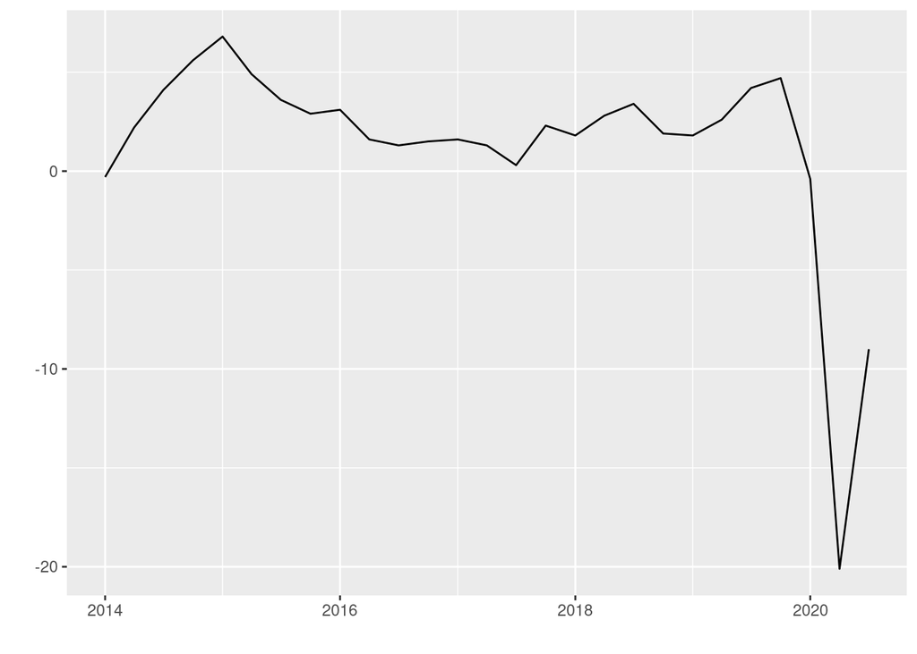

```r
autoplot(y.ts)
```

This shows no seasonality and appears to be a stationary process. We can confirm this by calculating the autocorrelation and partial autocorrelation functions.

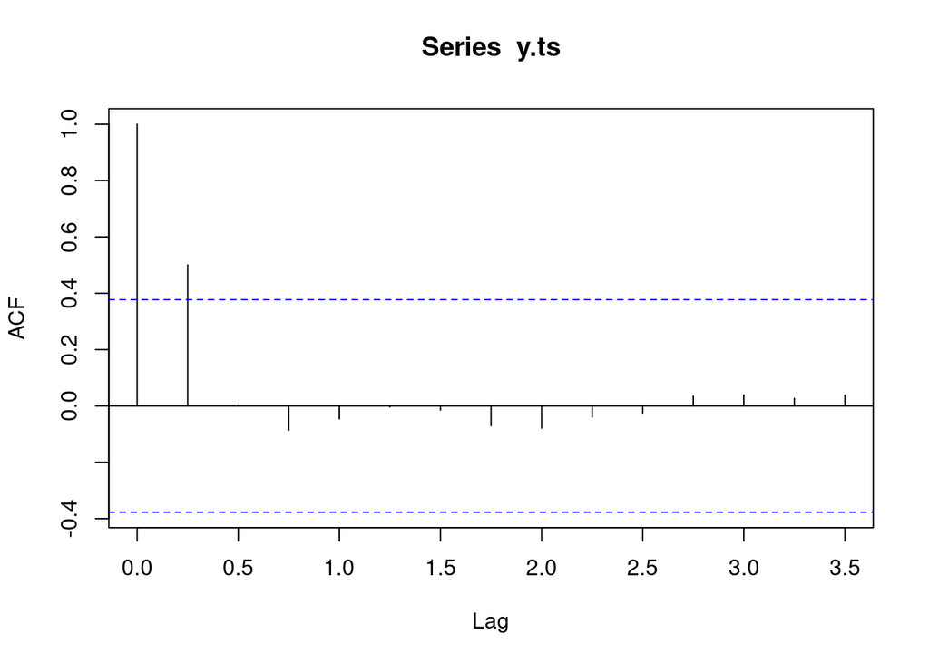

```r
acf(y.ts, plot = T)
```

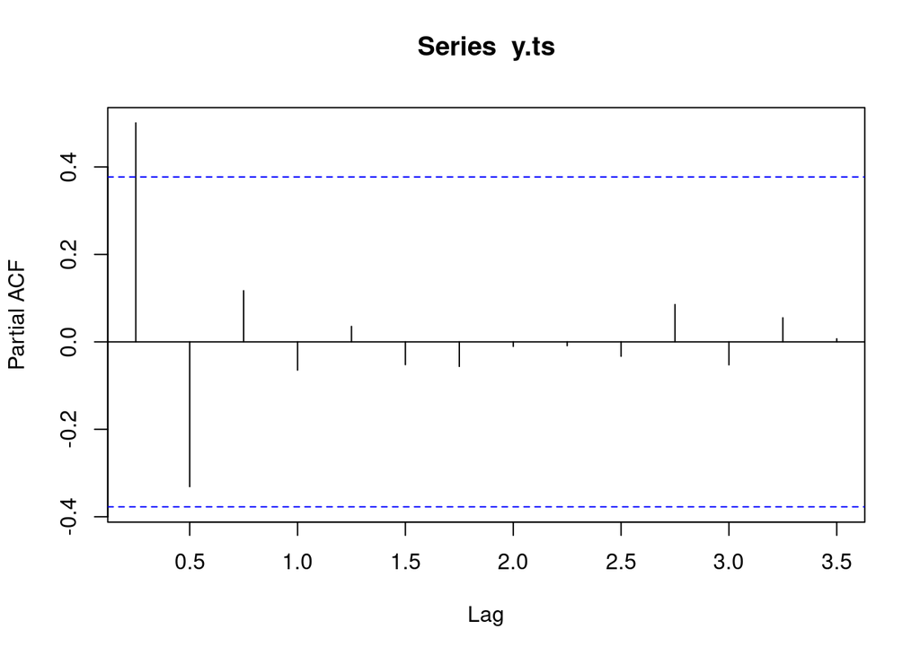

```r
pacf(y.ts, plot = T)
```

We can use `auto.arima()` to apply these heuristics to determine the correct specification for an ARIMA model.

```r
auto.arima(y.ts)
```

```
## Series: y.ts
## ARIMA(0,0,1) with zero mean
##
## Coefficients:
##          ma1
##       0.7343
## s.e.  0.2233
##
## sigma^2 estimated as 17.7:  log likelihood=-76.98
## AIC=157.96   AICc=158.46   BIC=160.56
```

```r
m1 <- Arima(y.ts, c(0,0,1))
summary(m1)
```

```
## Series: y.ts
## ARIMA(0,0,1) with non-zero mean
##
## Coefficients:
##          ma1    mean
##       0.7284  1.4107
## s.e.  0.2254  1.3314
##
## sigma^2 estimated as 17.68:  log likelihood=-76.43
## AIC=158.85   AICc=159.9   BIC=162.74
##
## Training set error measures:
##                     ME     RMSE      MAE      MPE     MAPE      MASE       ACF1
## Training set 0.0233512 4.045803 1.997741 57.76203 91.19075 0.6175813 0.01822874
```

This confirms that the likely model is an MA(1) model - the prediction error from the first lagged response is taken as an input in the next prediction. The coefficient estimate on this term is .7284 In other words, we predict the global mean $\mu$ for the first observation (t=0), and if we underpredict by $\epsilon_0$, then the prediction in the next period (t=1) is the mean plus the last error times .7284

$$y_t = \mu + .7284 \times \epsilon_{t-1}$$

Essentially, this means the process is more of a slow, smooth drift than a white noise.

## 3.2 MA(1) Model

Forecasts are not really possible beyond 1 period from an MA(1) model, since the prediction errors are unknown. Forecasts beyond 1 period are just the global mean.

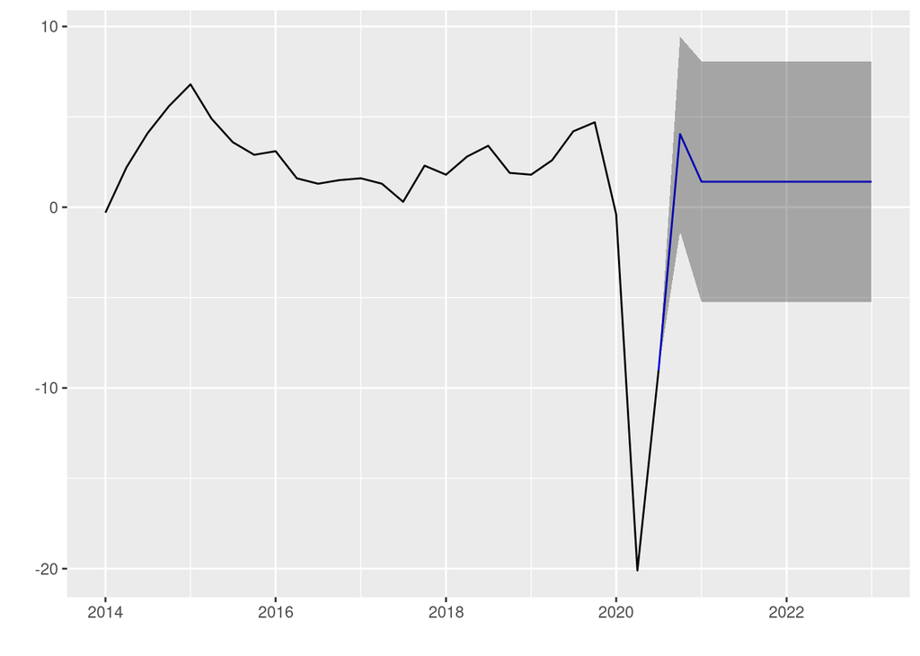

```r
forecast(m1, 10) %>% autoplot()
```

So there is not much useful info contained in past observations $y_t$ for forecasting - we will focus on exogenous predictors.

## 3.3 Disaggregate y

To work with exogenous predictors we need to have $y_t$ and $x_t$ at the same resolution. A common approach is to disaggregate the response via interpolation. We will do this with an interpolation that is constrained such that the mean interpolated value for the 3 months in any quarter is equal to the observed value for the quarter.

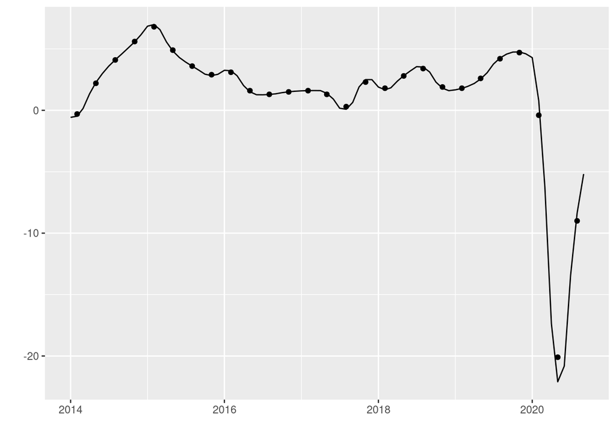

```r
y_disagg <- tempdisagg::td(y.ts ~ 1,
                           conversion = "average",
                           to = "monthly")
y.ts_month <- predict(y_disagg)

autoplot(y.ts_month) +
  geom_point(data = data.frame(y = y, date = seq(as.Date("2014/2/1"), as.Date("2020/9/1"), by = "quarter")),
             aes(x = date, y = y))
```

We have not interpolated beyond September 2020, leaving out the final quarter to forecast.

```r
tail(y.ts_month)
```

```
##             Apr        May        Jun        Jul        Aug        Sep
## 2020 -17.376946 -22.099349 -20.823704 -13.441642  -8.372554  -5.185804
```

### 3.3.1 Exogenous Predictors

I’m going to bind the features together, and we will line $x_t$ up with $y_t$ for the initial modeling. This may give good model results but it could be that the model is impractical. I do not know enough about the data collection process or how a forecast may be operationalized - maybe it is possible to obtain monthly values for $x_t$ (from the BLS and BEA releases) some time before the quarterly $y_t$ is publically available (e.g. before financial results are released by public companies). If it is, then this could be a fine setup if resulting forecasts have some value in that timeframe. If not, we need to time-shift our predictors in a way that better reflects the operational reality of our data generating process.

```r
x.ts <- ts(cbind(wide.bea %>% select(-c(year, month)),
                 wide.bls %>% select(-c(year, month))),
           frequency = 12)[1:81, ]
```

Identify features with many NA - these will not be useful for forecasting and would not be possible to fit in most models without imputation

```r
na_cnt <- apply(x.ts, 2, function(x) sum(is.na(x)))
keep_list <- na_cnt[na_cnt <= 5] %>% names
na_cnt[!(names(na_cnt) %in% keep_list)]
```

```
## PCU6211116211114111 PCU6211116211114112 PCU6211116211114113 PCU6211116211114114
##                  35                  35                  35                  35
## PCU6211116211114121 PCU6211116211114122 PCU6211116211114123 PCU6211116211114124
##                  35                  35                  35                  50
## PCU6211116211114131 PCU6211116211114132 PCU6211116211114133 PCU6211116211114134
##                  35                  35                  35                  35
## PCU6211116211114142 PCU6211116211114143 PCU6211116211114144 PCU6211116211114151
##                  35                  35                  35                  41
## PCU6211116211114152 PCU6211116211114153 PCU6211116211114154 PCU6211116211114191
##                  35                  35                  35                  35
## PCU6211116211114192 PCU6211116211114193 PCU6211116211114194 PCU6211116211115111
##                  35                  35                  35                  35
## PCU6211116211115112 PCU6211116211115113 PCU6211116211115114   PCU621210621210SM
##                  35                  35                  35                  28
##   PCU33911333911321  PCU621512621512421  PCU621512621512422
##                  35                  49                  49
```

We only have 81 observations of $y$, so we will remove these features with many `NA`. For those with fewer (5 or less) `NA`, we will use use Last Observation Carried Forward (LOCF) to handle most `NA`. This avoids introducing forward-looking info. For any `NA` appearing at the very start of a series, we impute the mean for the series so as to keep the observations for analysis.

```r
x.ts.glmnet <- x.ts[, keep_list] %>%
  imputeTS::na_locf(na_remaining = "mean")

sum(is.na(x.ts.glmnet))
```

```
## [1] 0
```

# 4 Modeling

## 4.1 Lasso

This first algorithm is similar to a standard MLE/OLS regression but differs in that it introduces a penalty term (L1 Norm) on model complexity. The penalized regression has the property of shrinking out small effects and keeping the strongest features. We will first tune the hyperparameter lambda via 5-fold cross-validation.

I am holding out the last 12 periods for validation purposes

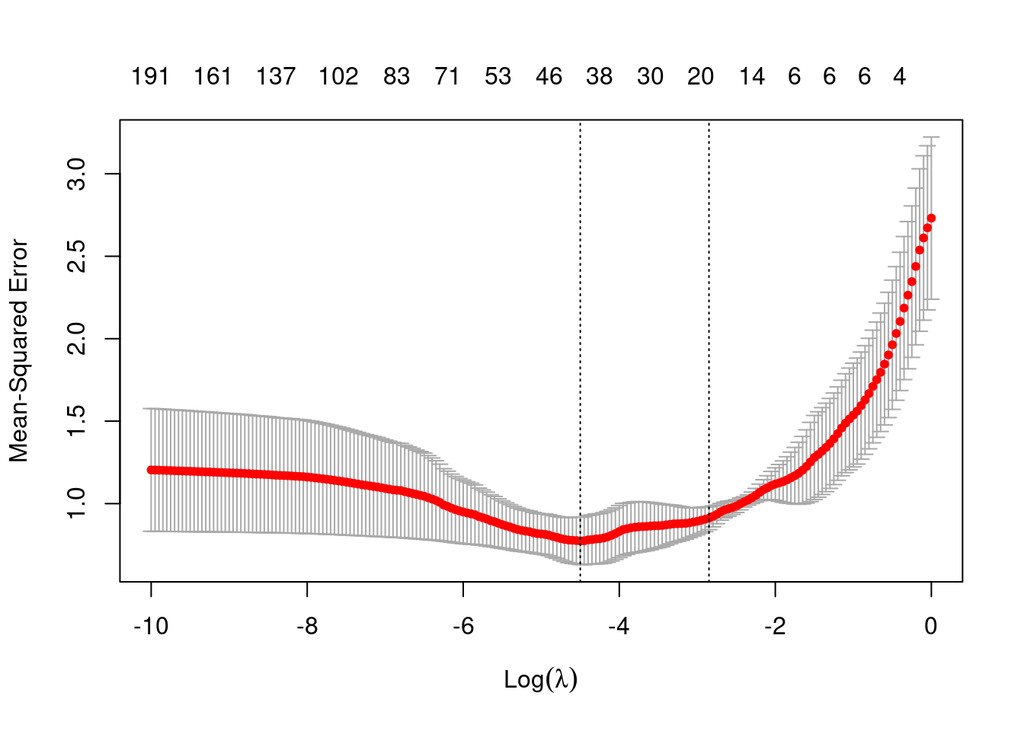

```r
set.seed(42)
cv.m2 <- cv.glmnet(x = x.ts.glmnet[1:69, ],
                   y = y.ts_month[1:69] %>% as.vector,
                   alpha = 1, ## LASSO
                   family = "gaussian",
                   standardize = TRUE,
                   lambda = exp(seq(-10, 0, .05)),
                   nfolds = 5)
plot(cv.m2)
```

I’ll choose the minimum prediction error lambda. Another common option is to choose the largest lambda which has estimated prediction error within 1 s.e. of the minimum. This gives a less complex model which is not **statistically** different in terms of the estimated prediction accuracy - it is often more robust to new data given due to greater parsimony.

```r
m2 <- glmnet( x = x.ts.glmnet[1:69,] %>% as.matrix,
              y = y.ts_month[1:69] %>% as.vector,
              alpha = 1, ## LASSO
              lambda = cv.m2$lambda.min,
              family = "gaussian",
              standardize = TRUE)
```

Finally, let’s forecast on the held-out 12 months and evaluate the accuracy.

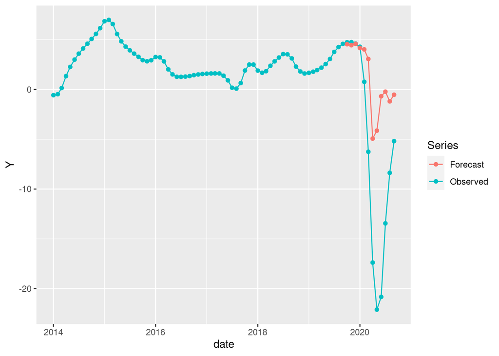

```r
preds <- predict(m2, newx = x.ts.glmnet %>% as.matrix, type = "response")

tibble(Observed = y.ts_month,
       date = seq(as.Date("2014/1/1"), as.Date("2020/9/1"), by = "month"),
       Forecast = c(rep(NA_real_, 69), preds[70:81])) %>%
  tidyr::gather(key = "Series", value = "Y", Observed, Forecast) %>%
  ggplot(aes(x = date, y = Y, color = Series)) +
  geom_line() +
  geom_point()
```

### 4.1.1 Lasso Top Features

We standardized covariates before fitting the regression, so parameter estimates are commensurable. They are ordered here by their magnitudes, with negative signs indicating inverse relationships to the response.

```r
a <- tibble(feature = rownames(coef(m2)),
            beta = coef(m2) %>% as.vector) %>%
  arrange(abs(beta) %>% desc) %>%
  left_join(dat.bea %>% select(SeriesLine, LineDescription),
            by = c("feature" = "SeriesLine")) %>%
  left_join(read.csv("bls.csv"),
            by = c("feature" = "Series")) %>%
  mutate(Description = case_when(is.na(Description) ~ LineDescription,
                                 TRUE ~ Description)) %>%
  select(-LineDescription)

a[2:30,]
```

| feature | beta | Description |
| --- | --- | --- |
| DNPNRA_184 | 0.29528505 | Nonprofit nursing homes' services to households |
| CES6562310007 | 0.17677893 | AVERAGE WEEKLY HOURS OF PRODUCTION AND NONSUPERVISORY EMPLOYEES Education and health services Nursing care facilities Seasonally Adjusted : CES6562310007 |
| PCU621111621111415 | -0.15889983 | Offices of physicians, except mental health Obstetrics/gynecology : PCU621111621111415 |
| DFPNRA_185 | -0.12114819 | Proprietary and government nursing homes |
| PCU62151162151124 | -0.10907541 | Medical laboratories Medicaid patients : PCU62151162151124 |
| DFPHRA_181 | 0.09199910 | Proprietary hospitals |
| DRXDRA_121 | 0.08835168 | Prescription drugs |
| PCU621111621111413 | 0.07259771 | Offices of physicians, except mental health General surgery and other surgical specialties : PCU621111621111413 |
| CES6562310034 | -0.06939599 | INDEXES OF AGGREGATE WEEKLY HOURS OF PRODUCTION AND NONSUPERVISORY EMPLOYEES, 2002=100 Education and health services Nursing care facilities Seasonally Adjusted : CES6562310034 |
| PCU62121062121032 | -0.06865752 | #N/A |

[output cut: 19 more lines]

### 4.1.2 Final LASSO

Assuming this was our best performing candidate model after a bakeoff, then we fit a final model in the same method as above but now using all of the available data.

```r
set.seed(42)
cv.final <- cv.glmnet(x = x.ts.glmnet,
                      y = y.ts_month %>% as.vector,
                      alpha = 1, ## LASSO
                      family = "gaussian",
                      standardize = TRUE,
                      lambda = exp(seq(-10, 0, .05)),
                      nfolds = 5)

m.final <- glmnet( x = x.ts.glmnet %>% as.matrix,
                   y = y.ts_month %>% as.vector,
                   alpha = 1, ## LASSO
                   lambda = cv.final$lambda.min,
                   family = "gaussian",
                   standardize = TRUE)
```

We generate a forecast for the final 3 months of 2020 (in case it is of interest to a reviewer), for which we know the values for $x_{i,t}$. For a quarterly estimate we can simply average the three results.

Note that we have `NA` observations for some of the in-model features, so we again use LOCF for imputation.

```r
newdata <- ts(cbind(wide.bea %>% select(-c(year, month)),
                    wide.bls %>% select(-c(year, month))),
              frequency = 12)[82:84, ]

forecast_monthly <- tibble(period = c("2020/10/1", "2020/11/1", "2020/12/1") %>% as.Date %>% format("%B %Y"),
                           forecast = predict(m.final, newx = newdata[, keep_list] %>%
                                                imputeTS::na_locf(),
                                              type = "response")[,1] )
forecast_monthly
```

| period | forecast |
| --- | --- |
| October 2020 | -5.003322 |
| November 2020 | -4.240224 |
| December 2020 | -4.760627 |

These are likely pretty poor forecasts because we are using machine learning techniques rather than a time series regression with exogenous features and bayesian priors informed by domain expertise. Even if we were to use lagged observations of Y (or $\epsilon$) in model estimation, we have not observed enough shocks in Y to inform a mean reversion component for the process. Finally, we only have 27 true observations of y (81 with interpolation) but we have 29 features selected by the Lasso. This means our model is essentially a ‘lookup’ to the historical observed values.

## 4.2 AR(3) with exogenous features

This is just meant to demonstrate an alternative approach for modeling this data - perhaps the default approach.

Suppose $x_t$ is not available in production at the time we need to forecast $y_t$. If that is true, then we would study the relationship between $Y$ and the predictors we do have at the time we create forecasts - “lagged” observations of $x$ (from prior periods). I will provide a simple demonstration using the **monthly** disaggregated data. We need to adjust the model for inference purposes - there will now of course be significant AR terms since we created each monthly $y_t$ by interpolating between quarterly observations. With this adjustment, we can make inferences about the relationships to the exogenous predictors.

We will choose just the top 5 features from the lasso regression earlier.

```r
## get top 5 features based on lasso selection
top5_x <- a %>% slice(2:6) %>% pull(feature)

## utility functions
lag_names <- paste("lag", formatC(1:3, width = nchar(max(1:3)), flag = "0"),
                   sep = "_")
lag_functions <- setNames(paste("dplyr::lag(., ", 1:3, ")"), lag_names)

## select the features and mutate the lags
lagged_x <- x.ts.glmnet %>%
  as_tibble() %>%
  select(all_of(top5_x)) %>%
  mutate_at(vars(top5_x), funs_(lag_functions)) %>%
  slice(-c(1:3)) %>% ## max lag is 3, so drop first 3 records for simplicity
  ts(start = c(2014, 4), frequency = 12)
```

Now we estimate the models for the first through third lags separately, including AR, I, and MA components

```r
m3.1 <- auto.arima(y.ts_month[4:69],
                   xreg = lagged_x[1:66, 6:10]) ## First lag of X

m3.2 <- auto.arima(y.ts_month[4:69],
                   xreg = lagged_x[1:66, 11:15]) ## Second lag of X

m3.3 <- auto.arima(y.ts_month[4:69],
                   xreg = lagged_x[1:66, 16:20]) ## Third lag of X
```

Summarizing the model with lag=1 - we see that an AR(3) process is now appropriate (an artifact of our dataset creation steps).

More importantly, we see comparatively small effects estimates for the lagged features.

```r
summary(m3.1)
```

```
## Series: y.ts_month[4:69]
## Regression with ARIMA(3,0,0) errors
##
## Coefficients:
##          ar1      ar2     ar3  DNPNRA_184_lag_1  CES6562310007_lag_1
##       2.1764  -1.7430  0.5316            0.0537              -0.0041
## s.e.  0.1032   0.1909  0.1053            0.0584               0.0109
##       PCU621111621111415_lag_1  DFPNRA_185_lag_1  PCU62151162151124_lag_1
##                         0.0170           -0.0248                   0.0084
## s.e.                    0.0115            0.0535                   0.0117
##
## sigma^2 estimated as 0.05839:  log likelihood=1.5
## AIC=15   AICc=18.22   BIC=34.71
##
## Training set error measures:
##                      ME      RMSE       MAE      MPE     MAPE      MASE
## Training set 0.01412039 0.2265168 0.1855705 4.764297 18.81565 0.4996338
##                    ACF1
## Training set 0.03564777
```

We can compare all 3 models using the corrected AIC metric (an estimate of out-of-sample prediction errors based on training deviance)

```r
m3.1$aicc
```

```
## [1] 18.21806
```

```r
m3.2$aicc
```

```
## [1] 18.694
```

```r
m3.3$aicc
```

```
## [1] 17.03308
```

This indicates `m3.3` is the best model

```r
summary(m3.3)
```

```
## Series: y.ts_month[4:69]
## Regression with ARIMA(3,0,0) errors
##
## Coefficients:
##          ar1      ar2     ar3  DNPNRA_184_lag_3  CES6562310007_lag_3
##       2.1825  -1.7416  0.5231            0.0989              -0.0087
## s.e.  0.1056   0.1955  0.1079            0.0551               0.0108
##       PCU621111621111415_lag_3  DFPNRA_185_lag_3  PCU62151162151124_lag_3
##                         0.0124           -0.0658                   0.0049
## s.e.                    0.0127            0.0508                   0.0116
##
## sigma^2 estimated as 0.05731:  log likelihood=2.09
## AIC=13.82   AICc=17.03   BIC=33.53
##
## Training set error measures:
##                      ME      RMSE       MAE      MPE     MAPE      MASE
## Training set 0.01604191 0.2244093 0.1827478 4.567153 16.87412 0.4920337
##                     ACF1
## Training set -0.02498937
```

# 5 Addendum

Given the linear dependence of the design matrix (having more predictors than observations), pre-processing approaches to reduce dimensionality can benefit prediction. The prior approaches relied on feature selection to reduce dimensionality. Another approach is use of a “Q-mode” PCA (principal components analysis) to construct an orthonormal basis `U` of `X` and select the first `k` orthogonal vectors containing most of the information in `X`.

## 5.1 PCA

First we perform the PCA using the same features used in the earlier lasso regression - those which did not suffer from high missingness.

```r
pca <- prcomp(x.ts.glmnet)
summary(pca)
```

```
## Importance of components:
##                             PC1      PC2      PC3      PC4     PC5     PC6
## Standard deviation     215.2589 69.96350 45.12489 38.41031 32.9544 27.0944
## Proportion of Variance   0.7637  0.08068  0.03356  0.02432  0.0179  0.0121
## Cumulative Proportion    0.7637  0.84442  0.87798  0.90230  0.9202  0.9323
##                             PC7      PC8      PC9     PC10     PC11    PC12
## Standard deviation     24.66179 23.32078 18.30464 17.37965 16.59279 15.1774
## Proportion of Variance  0.01002  0.00896  0.00552  0.00498  0.00454  0.0038
## Cumulative Proportion   0.94232  0.95128  0.95681  0.96179  0.96632  0.9701
##                            PC13     PC14    PC15    PC16     PC17    PC18
## Standard deviation     14.22865 13.07042 12.5525 11.5488 10.56504 9.70524
## Proportion of Variance  0.00334  0.00282  0.0026  0.0022  0.00184 0.00155
## Cumulative Proportion   0.97346  0.97627  0.9789  0.9811  0.98291 0.98446
##                           PC19    PC20    PC21    PC22    PC23    PC24    PC25
## Standard deviation     8.66047 8.11737 7.88169 7.54955 7.18684 6.84749 6.59436
## Proportion of Variance 0.00124 0.00109 0.00102 0.00094 0.00085 0.00077 0.00072
## Cumulative Proportion  0.98570 0.98678 0.98781 0.98875 0.98960 0.99037 0.99109
##                           PC26    PC27    PC28    PC29    PC30    PC31    PC32
## Standard deviation     6.40452 6.22118 5.89348 5.82047 5.32545 5.12067 4.98764
## Proportion of Variance 0.00068 0.00064 0.00057 0.00056 0.00047 0.00043 0.00041
## Cumulative Proportion  0.99176 0.99240 0.99297 0.99353 0.99400 0.99443 0.99484
##                           PC33    PC34    PC35    PC36    PC37    PC38    PC39
## Standard deviation     4.73765 4.61609 4.60008 4.33602 3.94203 3.85072 3.81497
## Proportion of Variance 0.00037 0.00035 0.00035 0.00031 0.00026 0.00024 0.00024
## Cumulative Proportion  0.99521 0.99556 0.99591 0.99622 0.99648 0.99672 0.99696
##                           PC40   PC41    PC42    PC43    PC44    PC45    PC46
## Standard deviation     3.65016 3.4774 3.42611 3.36778 3.27425 3.12318 2.98792
## Proportion of Variance 0.00022 0.0002 0.00019 0.00019 0.00018 0.00016 0.00015
## Cumulative Proportion  0.99718 0.9974 0.99757 0.99776 0.99794 0.99810 0.99825
##                           PC47    PC48    PC49   PC50   PC51    PC52    PC53
## Standard deviation     2.90252 2.71936 2.64056 2.5225 2.5087 2.35885 2.34905
## Proportion of Variance 0.00014 0.00012 0.00011 0.0001 0.0001 0.00009 0.00009
## Cumulative Proportion  0.99838 0.99851 0.99862 0.9987 0.9988 0.99892 0.99901
##                           PC54    PC55    PC56    PC57    PC58    PC59    PC60
## Standard deviation     2.17311 2.08850 2.05029 2.01384 1.89588 1.85051 1.79078
## Proportion of Variance 0.00008 0.00007 0.00007 0.00007 0.00006 0.00006 0.00005
## Cumulative Proportion  0.99909 0.99916 0.99923 0.99930 0.99936 0.99941 0.99947
##                           PC61    PC62    PC63    PC64    PC65    PC66    PC67
## Standard deviation     1.77358 1.68884 1.63339 1.61366 1.50088 1.48792 1.44083
## Proportion of Variance 0.00005 0.00005 0.00004 0.00004 0.00004 0.00004 0.00003
## Cumulative Proportion  0.99952 0.99957 0.99961 0.99965 0.99969 0.99973 0.99976
##                           PC68    PC69    PC70    PC71    PC72    PC73    PC74
## Standard deviation     1.34238 1.29166 1.19797 1.19122 1.16383 1.11213 1.05471
## Proportion of Variance 0.00003 0.00003 0.00002 0.00002 0.00002 0.00002 0.00002
## Cumulative Proportion  0.99979 0.99982 0.99984 0.99987 0.99989 0.99991 0.99993
##                           PC75    PC76    PC77    PC78    PC79    PC80
## Standard deviation     0.96261 0.94633 0.90214 0.84429 0.79869 0.70445
## Proportion of Variance 0.00002 0.00001 0.00001 0.00001 0.00001 0.00001
## Cumulative Proportion  0.99994 0.99996 0.99997 0.99998 0.99999 1.00000
##                                       PC81
## Standard deviation     0.00000000000009559
## Proportion of Variance 0.00000000000000000
## Cumulative Proportion  1.00000000000000000
```

The first component contains about 76% of the information in `X`; we an retain 95% of the information with just 8 components. This is relatively high (in my experience as a practitioner) and indicates strong correlations between the variables in `X` - not surprising as these features are all related to the same medical topic and all are hypothesized to correlate with `Y` by domain experts.

## 5.2 GAM Regression

```r
X_pca <- predict(pca, x.ts.glmnet)[,1:8]
X_pca %>% head
```

```
##            PC1       PC2       PC3        PC4       PC5        PC6        PC7
## [1,] -359.0218 -77.07663 -36.81094 -27.308124 50.525218 -27.473159   4.777386
## [2,] -349.9943 -73.87503 -35.29193 -10.607712 37.134590 -21.623886   7.637612
## [3,] -334.9368 -54.54381 -23.76696   2.371261 25.854136 -32.938572  -2.606516
## [4,] -334.8540 -71.65825 -24.49919 -18.439570 49.292360 -34.107151 -16.952417
## [5,] -335.2350 -59.51012 -30.20658 -22.855533 48.907605 -22.358093  -9.339109
## [6,] -329.0763 -22.62939 -34.72659   2.170506 -2.921365  -2.525718  16.893701
##            PC8
## [1,] -24.96433
## [2,] -32.75932
## [3,] -43.33516
## [4,] -28.85254
## [5,] -20.70527
## [6,] -42.72971
```

We need to construct the formula used by `mgcv::gam`.

```r
model_form <- formula(paste0("y ~ ", paste0("s(", colnames(X_pca), ", bs = 'ts', k=4)", collapse = " + ")))
model_form
```

```
## y ~ s(PC1, bs = "ts", k = 4) + s(PC2, bs = "ts", k = 4) + s(PC3,
##     bs = "ts", k = 4) + s(PC4, bs = "ts", k = 4) + s(PC5, bs = "ts",
##     k = 4) + s(PC6, bs = "ts", k = 4) + s(PC7, bs = "ts", k = 4) +
##     s(PC8, bs = "ts", k = 4)
```

Now we are ready to fit our additive model to just the first 69 periods, holding out 12 month for the out-of-time validation as we did earlier.

```r
m4 <- gam(model_form,
          data = tibble(y = y.ts_month) %>% bind_cols(., X_pca %>% as_tibble) %>% slice(1:69),
          family = gaussian(),
          method = "GCV.Cp",
          select = TRUE)

summary(m4)
```

```
##
## Family: gaussian
## Link function: identity
##
## Formula:
## y ~ s(PC1, bs = "ts", k = 4) + s(PC2, bs = "ts", k = 4) + s(PC3,
##     bs = "ts", k = 4) + s(PC4, bs = "ts", k = 4) + s(PC5, bs = "ts",
##     k = 4) + s(PC6, bs = "ts", k = 4) + s(PC7, bs = "ts", k = 4) +
##     s(PC8, bs = "ts", k = 4)
##
## Parametric coefficients:
##             Estimate Std. Error t value            Pr(>|t|)
## (Intercept)   2.6652     0.1017    26.2 <0.0000000000000002 ***
## ---
## Signif. codes:  0 '***' 0.001 '**' 0.01 '*' 0.05 '.' 0.1 ' ' 1
##
## Approximate significance of smooth terms:
##                    edf Ref.df      F              p-value
## s(PC1) 2.4681265658561      3 16.783 < 0.0000000000000002 ***
## s(PC2) 2.6545774136016      3 15.145 < 0.0000000000000002 ***
## s(PC3) 0.8871547142802      3  2.761              0.00106 **
## s(PC4) 0.9578228864656      3  2.503              0.00355 **
## s(PC5) 1.8637075128595      3  0.729              0.27824
## s(PC6) 1.6250798032189      3  0.997              0.14109
## s(PC7) 0.0000000002326      3  0.000              0.52433
## s(PC8) 0.7444133461952      3  0.646              0.07941 .
## ---
## Signif. codes:  0 '***' 0.001 '**' 0.01 '*' 0.05 '.' 0.1 ' ' 1
##
## R-sq.(adj) =  0.744   Deviance explained = 78.6%
## GCV = 0.86715  Scale est. = 0.71381   n = 69
```

The shrinkage penalty has entirely removed one term (PC7) from the fit, but all of our terms have been regularized or “shrunk” from the MLE. The edf (effective degrees of freedom) informs us how many “effective” parameters are estimated for each component. For deeper discussion on this, see [my blog post on GAMs](https://michael-barr.com/datasci/gams_scams_pt1). We do not care about training $R^2$ or reported p-values - the first is a terrible estimate of predictive accuracy (it always improves by adding more parameters to the model), and the latter does not indicate predictive power of effects but is only appropriate for statistical inference around effect size.

## 5.3 Forecast

Now we will again forecast out-of-time on the last 12 monthly periods (interpolated from 4 observed quarters)

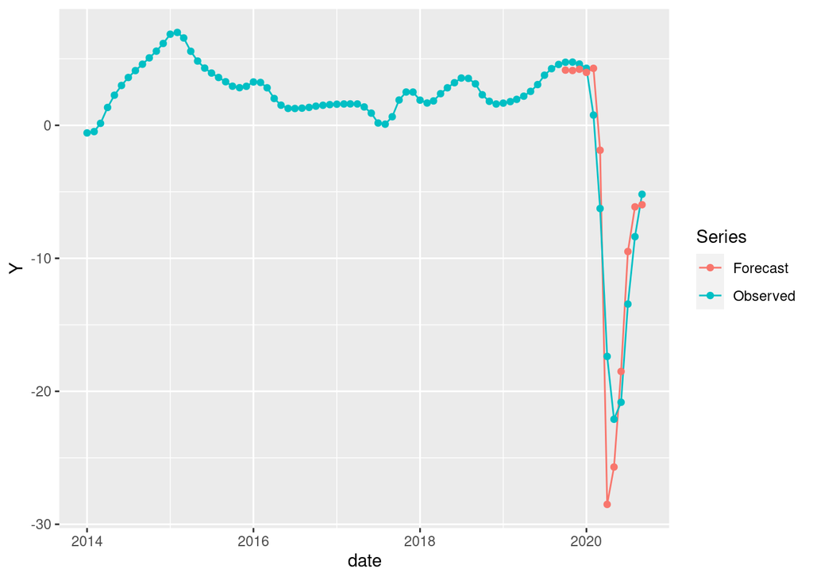

```r
gampreds <- predict(m4, newdata = X_pca[70:81, ] %>% as_tibble, type = "response")

tibble(Observed = y.ts_month,
       date = seq(as.Date("2014/1/1"), as.Date("2020/9/1"), by = "month"),
       Forecast = c(rep(NA_real_, 69), gampreds)) %>%
  tidyr::gather(key = "Series", value = "Y", Observed, Forecast) %>%
  ggplot(aes(x = date, y = Y, color = Series)) +
  geom_line() +
  geom_point()
```

## 5.4 Final GAM

Using all of the data

```r
gam.final <- gam(model_form,
                 data = tibble(y = y.ts_month) %>% cbind(., X_pca %>% as_tibble),
                 family = gaussian(),
                 method = "GCV.Cp",
                 select = TRUE)

summary(gam.final)
```

```
##
## Family: gaussian
## Link function: identity
##
## Formula:
## y ~ s(PC1, bs = "ts", k = 4) + s(PC2, bs = "ts", k = 4) + s(PC3,
##     bs = "ts", k = 4) + s(PC4, bs = "ts", k = 4) + s(PC5, bs = "ts",
##     k = 4) + s(PC6, bs = "ts", k = 4) + s(PC7, bs = "ts", k = 4) +
##     s(PC8, bs = "ts", k = 4)
##
## Parametric coefficients:
##             Estimate Std. Error t value            Pr(>|t|)
## (Intercept)   1.3519     0.1182   11.44 <0.0000000000000002 ***
## ---
## Signif. codes:  0 '***' 0.001 '**' 0.01 '*' 0.05 '.' 0.1 ' ' 1
##
## Approximate significance of smooth terms:
##                    edf Ref.df       F              p-value
## s(PC1) 2.9081532591445      3  27.933 < 0.0000000000000002 ***
## s(PC2) 2.9450915915155      3 307.239 < 0.0000000000000002 ***
## s(PC3) 0.0000000004043      3   0.000                0.311
## s(PC4) 0.6912179861836      3   0.500                0.134
## s(PC5) 0.1678261895946      3   0.095                0.184
## s(PC6) 2.9264247104466      3   7.884            0.0000948 ***
## s(PC7) 0.0000000006473      3   0.000                0.472
## s(PC8) 1.6404713286507      3   2.149                0.020 *
## ---
## Signif. codes:  0 '***' 0.001 '**' 0.01 '*' 0.05 '.' 0.1 ' ' 1
##
## R-sq.(adj) =  0.958   Deviance explained = 96.4%
## GCV =  1.334  Scale est. = 1.1317    n = 81
```

# 6 Model Save

For use in our Forecast as a Service (FaaS)

```r
list(varlist = keep_list, pca = pca, model = gam.final) %>%
  saveRDS("api/deploy.RDS")
```